# Keisham_Rishilumar_Project_Supervised_Learning

```python
import numpy as np
import pandas as pd
import seaborn as  sns
import matplotlib.pyplot as pyp
import scipy.stats as sts
from sklearn.linear_model import LinearRegression
from sklearn.model_selection import train_test_split
sns.set(color_codes=True)
%matplotlib inline
```

### 1. Data Understanding: [5 Marks]

A. Read all the 3 CSV files as DataFrame and store them into 3 separate variables. [1 Mark]

B. Print Shape and columns of all the 3 DataFrames. [1 Mark]

C. Compare Column names of all the 3 DataFrames and clearly write observations. [1 Mark]

D. Print DataTypes of all the 3 DataFrames. [1 Mark]

E. Observe and share variation in ‘Class’ feature of all the 3 DaraFrames. [1 Mark]

##### 1A . Read all the 3 CSV files as DataFrame and store them into 3 separate variables.

Solution 1 A :

```python
df_Normal = pd.read_csv('Normal.csv')
df_Normal.head(3)
```

|  | P_incidence | P_tilt | L_angle | S_slope | P_radius | S_Degree | Class |
| --- | --- | --- | --- | --- | --- | --- | --- |
| 0 | 38.505273 | 16.964297 | 35.112814 | 21.540976 | 127.632875 | 7.986683 | Normal |
| 1 | 54.920858 | 18.968430 | 51.601455 | 35.952428 | 125.846646 | 2.001642 | Normal |
| 2 | 44.362490 | 8.945435 | 46.902096 | 35.417055 | 129.220682 | 4.994195 | Normal |

```python
df_TypeH = pd.read_csv('Type_H.csv')
df_TypeH.head(3)
```

|  | P_incidence | P_tilt | L_angle | S_slope | P_radius | S_Degree | Class |
| --- | --- | --- | --- | --- | --- | --- | --- |
| 0 | 63.027817 | 22.552586 | 39.609117 | 40.475232 | 98.672917 | -0.254400 | Type_H |
| 1 | 39.056951 | 10.060991 | 25.015378 | 28.995960 | 114.405425 | 4.564259 | Type_H |
| 2 | 68.832021 | 22.218482 | 50.092194 | 46.613539 | 105.985135 | -3.530317 | Type_H |

```python
df_TypeS = pd.read_csv ('Type_S.csv')
df_TypeS.head(3)
```

|  | P_incidence | P_tilt | L_angle | S_slope | P_radius | S_Degree | Class |
| --- | --- | --- | --- | --- | --- | --- | --- |
| 0 | 74.377678 | 32.053104 | 78.772013 | 42.324573 | 143.560690 | 56.125906 | Type_S |
| 1 | 89.680567 | 32.704435 | 83.130732 | 56.976132 | 129.955476 | 92.027277 | Type_S |
| 2 | 44.529051 | 9.433234 | 52.000000 | 35.095817 | 134.711772 | 29.106575 | Type_S |

##### 1B. Print Shape and columns of all the 3 DataFrames.

Solution 1B:

```python
print ( 'Normal Shape : ',  df_Normal.shape)
print ( 'Normal Columns : ' , df_Normal.columns)
print ( 'TypeH Shape : ',  df_TypeH.shape)
print ( 'TypeH Columns : ' , df_TypeH.columns)
print ( 'TypeS Shape : ',  df_TypeS.shape)
print ( 'TypeS Columns : ' , df_TypeS.columns)
```

```
Normal Shape :  (100, 7)
Normal Columns :  Index(['P_incidence', 'P_tilt', 'L_angle', 'S_slope', 'P_radius', 'S_Degree',
       'Class'],
      dtype='object')
TypeH Shape :  (60, 7)
TypeH Columns :  Index(['P_incidence', 'P_tilt', 'L_angle', 'S_slope', 'P_radius', 'S_Degree',
       'Class'],
      dtype='object')
TypeS Shape :  (150, 7)
TypeS Columns :  Index(['P_incidence', 'P_tilt', 'L_angle', 'S_slope', 'P_radius', 'S_Degree',
       'Class'],
      dtype='object')
```

##### 1C. Compare Column names of all the 3 DataFrames and clearly write observations.

Solution 1C:

```python
columns_normal=df_Normal.columns
columns_typeH=df_TypeH.columns
commonNormal_H = columns_normal.intersection(columns_typeH)
diffNormal_H = columns_normal.difference(columns_typeH)
print ('Common columns between Normal and Type H' , commonNormal_H)
print ('Differnce in  columns between Normal and Type H' , diffNormal_H)
```

```
Common columns between Normal and Type H Index(['P_incidence', 'P_tilt', 'L_angle', 'S_slope', 'P_radius', 'S_Degree',
       'Class'],
      dtype='object')
Differnce in  columns between Normal and Type H Index([], dtype='object')
```

```python
columns_typeS=df_TypeS.columns
commonNormal_S = columns_normal.intersection(columns_typeS)
diffNormal_S = columns_normal.difference(columns_typeS)
print ('Common columns between Normal and Type S' , commonNormal_S)
print ('Differnce in  columns between Normal and Type S' , diffNormal_S)
```

```
Common columns between Normal and Type S Index(['P_incidence', 'P_tilt', 'L_angle', 'S_slope', 'P_radius', 'S_Degree',
       'Class'],
      dtype='object')
Differnce in  columns between Normal and Type S Index([], dtype='object')
```

```python
commonH_S = columns_typeH.intersection(columns_typeS)
diffH_S = columns_typeH.difference(columns_typeS)
print ('Common columns between Type H and Type S' , commonH_S)
print ('Differnce in  columns between Type H and Type S' , diffH_S)
```

```
Common columns between Type H and Type S Index(['P_incidence', 'P_tilt', 'L_angle', 'S_slope', 'P_radius', 'S_Degree',
       'Class'],
      dtype='object')
Differnce in  columns between Type H and Type S Index([], dtype='object')
```

##### All the 3 Data Frame have the same Columns name , however some of the column value are quite different and shall be analyse carefully.

##### 1D. Print DataTypes of all the 3 DataFrames

Solutuon 1D:

```python
df_Normal.dtypes
```

```
P_incidence    float64
P_tilt         float64
L_angle        float64
S_slope        float64
P_radius       float64
S_Degree       float64
Class           object
dtype: object
```

```python
df_TypeH.dtypes
```

```
P_incidence    float64
P_tilt         float64
L_angle        float64
S_slope        float64
P_radius       float64
S_Degree       float64
Class           object
dtype: object
```

```python
df_TypeS.dtypes
```

```
P_incidence    float64
P_tilt         float64
L_angle        float64
S_slope        float64
P_radius       float64
S_Degree       float64
Class           object
dtype: object
```

##### 1E. Observe and share variation in ‘Class’ feature of all the 3 DataFrames.

Solution 1E:

```python
df_Normal['Class'].unique()
```

```
array(['Normal', 'Nrmal'], dtype=object)
```

```python
df_TypeH['Class'].unique()
```

```
array(['Type_H', 'type_h'], dtype=object)
```

```python
df_TypeS['Class'].unique()
```

```
array(['Type_S', 'tp_s'], dtype=object)
```

##### Conclusion : For a particular Dataframe , the "Class" variable has more than one value, this means it needs a clean up.

### 2. Data Preparation and Exploration:

A. Unify all the variations in ‘Class’ feature for all the 3 DataFrames. [1 Marks]

For Example: ‘tp_s’, ‘Type_S’, ‘type_s’ should be converted to ‘type_s’

B. Combine all the 3 DataFrames to form a single DataFrame [1 Marks] Checkpoint: Expected Output shape = (310,7)

C. Print 5 random samples of this DataFrame [1 Marks]

D. Print Feature-wise percentage of Null values. [1 Mark]

E. Check 5-point summary of the new DataFrame. [1 Mark]

##### 2A. Unify all the variations in ‘Class’ feature for all the 3 DataFrames.

Solution 2A:

```python
df_Normal['Class'] = 'Normal'
df_Normal['Class'].unique()
```

```
array(['Normal'], dtype=object)
```

```python
df_TypeH['Class'] = 'type_h'
df_TypeH['Class'].unique()
```

```
array(['type_h'], dtype=object)
```

```python
df_TypeS['Class'] = 'type_s'
df_TypeS['Class'].unique()
```

```
array(['type_s'], dtype=object)
```

##### 2B. Combine all the 3 DataFrames to form a single DataFrame.

Solution 2B:

```python
master_df = pd.concat([df_Normal,df_TypeH, df_TypeS] , axis=0)
master_df.shape
```

```
(310, 7)
```

```python
master_df.head()
```

|  | P_incidence | P_tilt | L_angle | S_slope | P_radius | S_Degree | Class |
| --- | --- | --- | --- | --- | --- | --- | --- |
| 0 | 38.505273 | 16.964297 | 35.112814 | 21.540976 | 127.632875 | 7.986683 | Normal |
| 1 | 54.920858 | 18.968430 | 51.601455 | 35.952428 | 125.846646 | 2.001642 | Normal |
| 2 | 44.362490 | 8.945435 | 46.902096 | 35.417055 | 129.220682 | 4.994195 | Normal |
| 3 | 48.318931 | 17.452121 | 48.000000 | 30.866809 | 128.980308 | -0.910941 | Normal |
| 4 | 45.701789 | 10.659859 | 42.577846 | 35.041929 | 130.178314 | -3.388910 | Normal |

```python
master_df.tail()
```

|  | P_incidence | P_tilt | L_angle | S_slope | P_radius | S_Degree | Class |
| --- | --- | --- | --- | --- | --- | --- | --- |
| 145 | 80.111572 | 33.942432 | 85.101608 | 46.169139 | 125.593624 | 100.292107 | type_s |
| 146 | 95.480229 | 46.550053 | 59.000000 | 48.930176 | 96.683903 | 77.283072 | type_s |
| 147 | 74.094731 | 18.823727 | 76.032156 | 55.271004 | 128.405731 | 73.388216 | type_s |
| 148 | 87.679087 | 20.365613 | 93.822416 | 67.313473 | 120.944829 | 76.730629 | type_s |
| 149 | 48.259920 | 16.417462 | 36.329137 | 31.842457 | 94.882336 | 28.343799 | type_s |

##### 3C. Print 5 random samples of this DataFrame

Solution 3C:

```python
master_df.sample(n=5, random_state=2)
```

|  | P_incidence | P_tilt | L_angle | S_slope | P_radius | S_Degree | Class |
| --- | --- | --- | --- | --- | --- | --- | --- |
| 12 | 84.974132 | 33.021175 | 60.859873 | 51.952957 | 125.659534 | 74.333409 | type_s |
| 114 | 61.411737 | 25.384364 | 39.096869 | 36.027373 | 103.404597 | 21.843407 | type_s |
| 7 | 38.126589 | 6.557617 | 50.445075 | 31.568971 | 132.114805 | 6.338199 | Normal |
| 84 | 46.236399 | 10.062770 | 37.000000 | 36.173629 | 128.063620 | -5.100053 | Normal |
| 54 | 80.988074 | 36.843172 | 86.960602 | 44.144903 | 141.088149 | 85.872152 | type_s |

##### 2D. Print Feature-wise percentage of Null values

Soluton 2D:

```python
print (master_df.isnull().sum())
print ('As such there are no null chracters in the dataframe , Therefore percesntag will be 0')
```

```
P_incidence    0
P_tilt         0
L_angle        0
S_slope        0
P_radius       0
S_Degree       0
Class          0
dtype: int64
As such there are no null chracters in the dataframe , Therefore percesntag will be 0
```

##### 2E. Check 5-point summary of the new DataFrame.

Solution 2E:

```python
summary_5pt = master_df.describe()
summary_5pt.loc['min':'max',:]
```

|  | P_incidence | P_tilt | L_angle | S_slope | P_radius | S_Degree |
| --- | --- | --- | --- | --- | --- | --- |
| min | 26.147921 | -6.554948 | 14.000000 | 13.366931 | 70.082575 | -11.058179 |
| 25% | 46.430294 | 10.667069 | 37.000000 | 33.347122 | 110.709196 | 1.603727 |
| 50% | 58.691038 | 16.357689 | 49.562398 | 42.404912 | 118.268178 | 11.767934 |
| 75% | 72.877696 | 22.120395 | 63.000000 | 52.695888 | 125.467674 | 41.287352 |
| max | 129.834041 | 49.431864 | 125.742385 | 121.429566 | 163.071041 | 418.543082 |

### 3. Data Analysis: [10 Marks]

A. Visualize a heatmap to understand correlation between all features [2 Marks]

B. Share insights on correlation. [2 Marks]

```
    A. Features having stronger correlation with correlation value.

    B. Features having weaker correlation with correlation value.
```

C. Visualize a pairplot with 3 classes distinguished by colors and share insights. [2 Marks]

D. Visualize a jointplot for ‘P_incidence’ and ‘S_slope’ and share insights. [2 Marks]

E. Visualize a boxplot to check distribution of the features and share insights. [2 Marks]

##### 3A. Visualize a heatmap to understand correlation between all features.

Solution 3A:

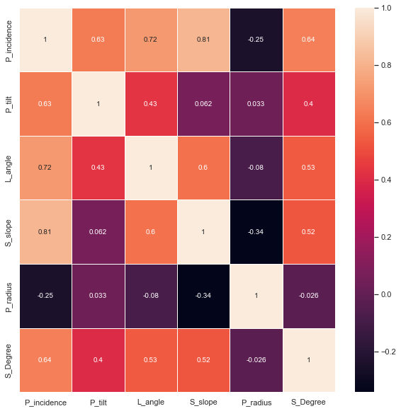

```python
fig, ax = pyp.subplots(figsize=(10, 10))
sns.heatmap(master_df.corr() , annot=True, linewidths='0.5', ax=ax);
```

##### 3B. Share insights on correlation. [2 Marks

P_incident and S_slope has very positive correlation wit vlaue of 0.81. Similarly P_incident and S_Degree, P_incident and L_angle do have a good postive correlation. Please refer the scatter plot below.

```
Positive Coorelation
```

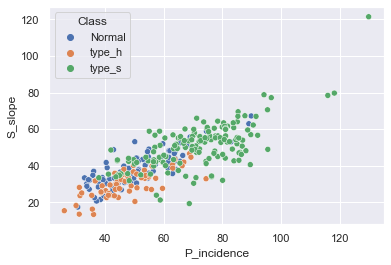

```python
print ("Positive Coorelation")
sns.scatterplot(x=master_df['P_incidence'], y=master_df['S_slope'], hue=master_df['Class']);
```

```
Negative Coorelation
```

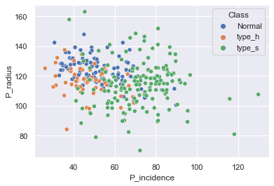

```python
print ("Negative Coorelation")
sns.scatterplot(x=master_df['P_incidence'], y=master_df['P_radius'], hue=master_df['Class']);
```

##### 3C. Visualize a pairplot with 3 classes distinguished by colors and share insights.

Solution 3C

```python
master_df_copy = master_df
#resetting the Index.
master_df.reset_index(drop=True,inplace=True)
master_df.index.is_unique
```

```
True
```

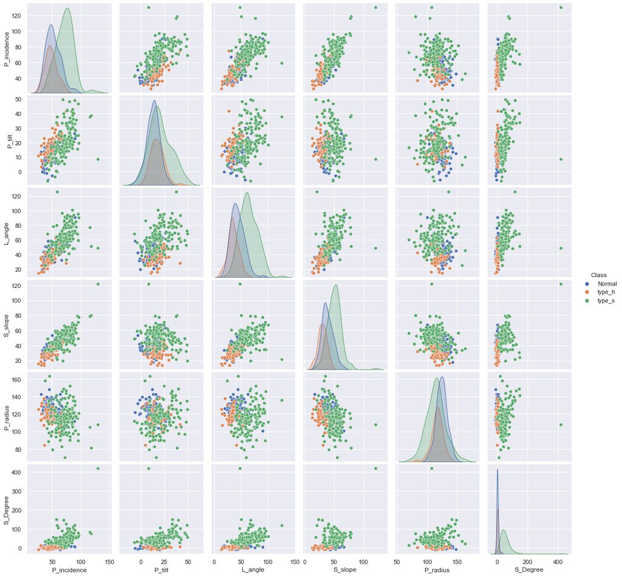

```python
sns.pairplot(master_df, hue='Class');
```

##### 3D. Visualize a jointplot for ‘P_incidence’ and ‘S_slope’ and share insights.

Solution 3D

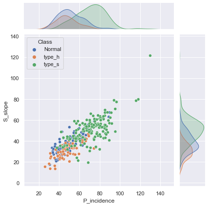

```python
sns.jointplot(x= master_df['P_incidence'] , y=master_df['S_slope'] , hue=master_df['Class']);
#master_df.head()
```

#### The two variable has a very strong positive correlation for all the Class type Normal, type_h and type_s.

##### 3E. Visualize a boxplot to check distribution of the features and share insights.

Solution 3E:

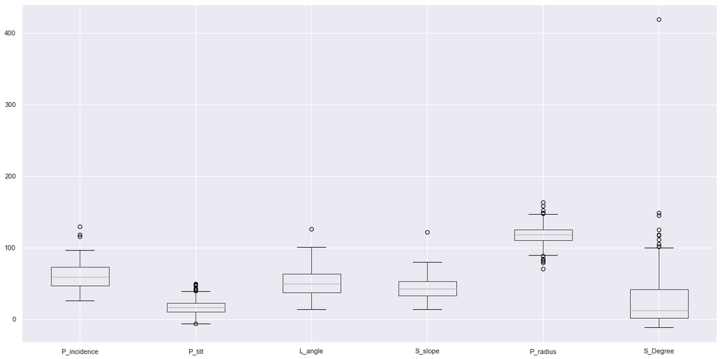

```python
pyp.figure(figsize=(20, 10))
master_df.boxplot()
pyp.show()
```

##### Features 'L_angle' and 'S_slope' has one outliers each. Features 'P_incidence' 'P_Tilt' and 'S_Degree' has some outliers which are more than their respective Max values. Feature 'P_radius' has outliers in both Min and Max Side. As its a Medical data , this need a good amount of EDA and data treating.

### 4. Model Building: [6 Marks]

A. Split data into X and Y. [1 Marks]

B. Split data into train and test with 80:20 proportion. [1 Marks]

C. Train a Supervised Learning Classification base model using KNN classifier. [2 Marks]

D. Print all the possible performance metrics for both train and test data. [2 Marks]

##### 4A. Split data into X and Y

Solution 4A:

```python
x = master_df.drop('Class', axis=1)
y = master_df['Class']
```

##### 4B. Split data into train and test with 80:20 proportion.

Solution 4B:

```python
x_train, x_test, y_train, y_test = train_test_split(x, y, test_size=0.20 , random_state=2)
print ('x_train: ' , x_train.shape, 'y_train: ', y_train.shape)
print ('x_test: ' , x_test.shape, 'y_test: ', y_test.shape)
```

```
x_train:  (248, 6) y_train:  (248,)
x_test:  (62, 6) y_test:  (62,)
```

##### 4C. Train a Supervised Learning Classification base model using KNN classifier .

Solution 4C:

```python
from scipy.stats import zscore
from sklearn.neighbors import  KNeighborsClassifier
from sklearn import metrics

knnc = KNeighborsClassifier(n_neighbors= 5, weights='distance')
knnc.fit(x_train, y_train)
```

```
KNeighborsClassifier(weights='distance')
```

```python
train_predict = knnc.predict(x_train)
trainscore = metrics.accuracy_score(y_train, train_predict)
test_predict = knnc.predict(x_test)
testscore = metrics.accuracy_score(y_test, test_predict)
print ('trainscore = ',   trainscore, ' testscore = ' ,  testscore)
```

```
trainscore =  1.0  testscore =  0.8064516129032258
```

##### 4D. Print all the possible performance metrics for both train and test data

Solution 4D:

```python
print (metrics.classification_report (y_test, test_predict) )
```

```
              precision    recall  f1-score   support

      Normal       0.67      0.84      0.74        19
      type_h       0.50      0.36      0.42        11
      type_s       1.00      0.94      0.97        32

    accuracy                           0.81        62
   macro avg       0.72      0.71      0.71        62
weighted avg       0.81      0.81      0.80        62
```

```python
#Accuracy score
print (knnc.score(x_train, y_train))
print (knnc.score(x_test, y_test))
```

```
1.0
0.8064516129032258
```

```python
#Cross tabulation
print(pd.crosstab(y_test, test_predict, rownames=['Real'], colnames=['Predicted'], margins=True, margins_name='total'))
```

```
Predicted  Normal  type_h  type_s  total
Real
Normal         16       3       0     19
type_h          7       4       0     11
type_s          1       1      30     32
total          24       8      30     62
```

### 5. Performance Improvement: [4 Marks]

A. Experiment with various parameters to improve performance of the base model. [2 Marks] (Optional: Experiment with various Hyperparameters - Research required)

B. Clearly showcase improvement in performance achieved. [1 Marks] For Example:

```
    A. Accuracy: +15% improvement
    B. Precision: +10% improvement.
```

C. Clearly state which parameters contributed most to improve model performance. [1 Marks]

##### 5A. Experiment with various parameters to improve performance of the base model.

Solution 5A:

```python
#As we do not know the units of the attirbutes it is good to consider zscore.
x_copy = x
x1_scaled = x_copy.apply(zscore)
knnc_scaled = KNeighborsClassifier(n_neighbors= 5, weights='distance')
xs_train, xs_test, ys_train, ys_test = train_test_split(x1_scaled, y, test_size=0.20 , random_state=1)
knnc_scaled.fit(xs_train, ys_train)
#Accuracy score
print (knnc_scaled.score(xs_train, ys_train))
print (knnc_scaled.score(xs_test, ys_test))
ys_predict = knnc_scaled.predict(xs_test)

print (metrics.classification_report (ys_test, ys_predict) )
print ('Applying zscore does not improve the accuracy or the precision')
```

```
1.0
0.7258064516129032
              precision    recall  f1-score   support

      Normal       0.57      0.67      0.62        18
      type_h       0.64      0.64      0.64        11
      type_s       0.87      0.79      0.83        33

    accuracy                           0.73        62
   macro avg       0.69      0.70      0.69        62
weighted avg       0.74      0.73      0.73        62

Applying zscore does not improve the accuracy or the precision
```

```python
knnc_new = KNeighborsClassifier(n_neighbors= 5, weights='distance')
xn_train, xn_test, yn_train, yn_test = train_test_split(x, y, test_size=0.20 , random_state=5)
knnc_new.fit(xn_train, yn_train)
print (knnc_new.score(xn_train, yn_train))
print (knnc_new.score(xn_test, yn_test))
yn_predict = knnc_new.predict(xn_test)

print (metrics.classification_report (yn_test, yn_predict) )
print ('Increasing the random_state to 5 improves the accuracy and precision by 11% and 13% resptively for Normal.')
print ('Beyond random state = 5 the accuracy and precision drops')
```

```
1.0
0.9193548387096774
              precision    recall  f1-score   support

      Normal       0.80      1.00      0.89        20
      type_h       1.00      0.56      0.71         9
      type_s       1.00      0.97      0.98        33

    accuracy                           0.92        62
   macro avg       0.93      0.84      0.86        62
weighted avg       0.94      0.92      0.91        62

Increasing the random_state to 5 improves the accuracy and precision by 11% and 13% resptively for Normal.
Beyond random state = 5 the accuracy and precision drops
```

##### 5B. Clearly showcase improvement in performance achieved.

Solution 5B

```python
print ('Original accuracy :' ,0.8064516129032258 , 'Improved accuracy : ',  0.9193548387096774)
print ('Original precision, recall, f1-score for Normal : ', '0.67, 0.84, 0.74', 'Improved precision for Normal, recall, f1-score : ', '0.80, 1.0, 0.89' )
print ('Original precision, recall, f1-score for type_h : ', '0.50, 0.36, 0.42', 'Improved precision for type_h , recall, f1-score: ', '1, 0.56, 0.71' )
print ('Original precision, recall, f1-score for type_s : ', '1.0, 0.94, 0.97', 'Improved precision for type_h , recall, f1-score: ', ' 1 , 0.97, 0.98' )
print ('Increasing the random_state to 5 improves the accuracy and precision by 11% and 13% resptively for Normal')
print ('Beyond random state = 5 the accuracy and precision drops')
```

```
Original accuracy : 0.8064516129032258 Improved accuracy :  0.9193548387096774
Original precision, recall, f1-score for Normal :  0.67, 0.84, 0.74 Improved precision for Normal, recall, f1-score :  0.80, 1.0, 0.89
Original precision, recall, f1-score for type_h :  0.50, 0.36, 0.42 Improved precision for type_h , recall, f1-score:  1, 0.56, 0.71
Original precision, recall, f1-score for type_s :  1.0, 0.94, 0.97 Improved precision for type_h , recall, f1-score:   1 , 0.97, 0.98
Increasing the random_state to 5 improves the accuracy and precision by 11% and 13% resptively for Normal
Beyond random state = 5 the accuracy and precision drops
```

##### 5C. Clearly state which parameters contributed most to improve model performance

Solution 5C:

##### In this case 'zscore' was not so helpful. Also 'n_neighbors' and 'test_size' were tried but these reduced the Accurracy.

'random_state=5' gave the best score.

### PARTB:

1. Data Understanding and Preparation: [5 Marks]

   A. Read both the Datasets ‘Data1’ and ‘Data 2’ as DataFrame and store them into two separate variables. [1 Marks]

   B. Print shape and Column Names and DataTypes of both the Dataframes. [1 Marks]

   C. Merge both the Dataframes on ‘ID’ feature to form a single DataFrame [2 Marks]

   D. Change Datatype of below features to ‘Object’ [1 Marks] ‘CreditCard’, ‘InternetBanking’, ‘FixedDepositAccount’, ‘Security’, ‘Level’, ‘HiddenScore’.

   ```
    [Reason behind performing this operation:- Values in these features are binary i.e. 1/0. But DataType is ‘int’/’float’ which is not expected.]
   ```

##### 1A. Read both the Datasets ‘Data1’ and ‘Data 2’ as DataFrame and store them into two separate variables:

Solution : 1A

```python
df_data1 = pd.read_csv('2_Data1.csv')
df_data2 = pd.read_csv('2_Data2.csv')
df_data1.head()
```

|  | ID | Age | CustomerSince | HighestSpend | ZipCode | HiddenScore | MonthlyAverageSpend | Level |
| --- | --- | --- | --- | --- | --- | --- | --- | --- |
| 0 | 1 | 25 | 1 | 49 | 91107 | 4 | 1.6 | 1 |
| 1 | 2 | 45 | 19 | 34 | 90089 | 3 | 1.5 | 1 |
| 2 | 3 | 39 | 15 | 11 | 94720 | 1 | 1.0 | 1 |
| 3 | 4 | 35 | 9 | 100 | 94112 | 1 | 2.7 | 2 |
| 4 | 5 | 35 | 8 | 45 | 91330 | 4 | 1.0 | 2 |

```python
df_data2.head()
```

|  | ID | Mortgage | Security | FixedDepositAccount | InternetBanking | CreditCard | LoanOnCard |
| --- | --- | --- | --- | --- | --- | --- | --- |
| 0 | 1 | 0 | 1 | 0 | 0 | 0 | NaN |
| 1 | 2 | 0 | 1 | 0 | 0 | 0 | NaN |
| 2 | 3 | 0 | 0 | 0 | 0 | 0 | NaN |
| 3 | 4 | 0 | 0 | 0 | 0 | 0 | NaN |
| 4 | 5 | 0 | 0 | 0 | 0 | 1 | NaN |

##### 1B. Print shape and Column Names and DataTypes of both the Dataframes.

Solution 1B:

```python
print ('Shape_data1: ', df_data1.shape, 'Shape_data2: ' , df_data2.shape )
print ('Columns data1: ', df_data1.columns )
print ('Columns data2: ' , df_data2.columns )
print ('Data Types data1: ', df_data1.dtypes )
print ('Data Types data12: ', df_data2.dtypes )
```

```
Shape_data1:  (5000, 8) Shape_data2:  (5000, 7)
Columns data1:  Index(['ID', 'Age', 'CustomerSince', 'HighestSpend', 'ZipCode', 'HiddenScore',
       'MonthlyAverageSpend', 'Level'],
      dtype='object')
Columns data2:  Index(['ID', 'Mortgage', 'Security', 'FixedDepositAccount', 'InternetBanking',
       'CreditCard', 'LoanOnCard'],
      dtype='object')
Data Types data1:  ID                       int64
Age                      int64
CustomerSince            int64
HighestSpend             int64
ZipCode                  int64
HiddenScore              int64
MonthlyAverageSpend    float64
Level                    int64
dtype: object
Data Types data12:  ID                       int64
Mortgage                 int64
Security                 int64
FixedDepositAccount      int64
InternetBanking          int64
CreditCard               int64
LoanOnCard             float64
dtype: object
```

##### 1C. Merge both the Dataframes on ‘ID’ feature to form a single DataFrame

Soltion 1C:

```python
Master_data = pd.merge(df_data1,df_data2, how='outer', on='ID')
print ('Shape : ', Master_data.shape)
Master_data.head()
```

```
Shape :  (5000, 14)
```

|  | ID | Age | CustomerSince | HighestSpend | ZipCode | HiddenScore | MonthlyAverageSpend | Level | Mortgage | Security | FixedDepositAccount | InternetBanking | CreditCard | LoanOnCard |
| --- | --- | --- | --- | --- | --- | --- | --- | --- | --- | --- | --- | --- | --- | --- |
| 0 | 1 | 25 | 1 | 49 | 91107 | 4 | 1.6 | 1 | 0 | 1 | 0 | 0 | 0 | NaN |
| 1 | 2 | 45 | 19 | 34 | 90089 | 3 | 1.5 | 1 | 0 | 1 | 0 | 0 | 0 | NaN |
| 2 | 3 | 39 | 15 | 11 | 94720 | 1 | 1.0 | 1 | 0 | 0 | 0 | 0 | 0 | NaN |
| 3 | 4 | 35 | 9 | 100 | 94112 | 1 | 2.7 | 2 | 0 | 0 | 0 | 0 | 0 | NaN |
| 4 | 5 | 35 | 8 | 45 | 91330 | 4 | 1.0 | 2 | 0 | 0 | 0 | 0 | 1 | NaN |

##### 1D. Change Datatype of below features to ‘Object’ .

‘CreditCard’, ‘InternetBanking’, ‘FixedDepositAccount’, ‘Security’, ‘Level’, ‘HiddenScore’.

Solution 1D:

```python
Master_data.dtypes
```

```
ID                       int64
Age                      int64
CustomerSince            int64
HighestSpend             int64
ZipCode                  int64
HiddenScore              int64
MonthlyAverageSpend    float64
Level                    int64
Mortgage                 int64
Security                 int64
FixedDepositAccount      int64
InternetBanking          int64
CreditCard               int64
LoanOnCard             float64
dtype: object
```

```python
Master_data['CreditCard'] = Master_data['CreditCard'].astype(str)
Master_data['InternetBanking'] = Master_data['InternetBanking'].astype(str)
Master_data['FixedDepositAccount'] = Master_data['FixedDepositAccount'].astype(str)
Master_data['Security'] = Master_data['Security'].astype(str)
Master_data['Level'] = Master_data['Level'].astype(str)
Master_data['HiddenScore'] = Master_data['HiddenScore'].astype(str)
Master_data.dtypes
```

```
ID                       int64
Age                      int64
CustomerSince            int64
HighestSpend             int64
ZipCode                  int64
HiddenScore             object
MonthlyAverageSpend    float64
Level                   object
Mortgage                 int64
Security                object
FixedDepositAccount     object
InternetBanking         object
CreditCard              object
LoanOnCard             float64
dtype: object
```

### 2. Data Exploration and Analysis: [5 Marks]

A. Visualize distribution of Target variable ‘LoanOnCard’ and clearly share insights. [2 Marks]

B. Check the percentage of missing values and impute if required. [1 Marks]

C. Check for unexpected values in each categorical variable and impute with best suitable value. [2 Marks]

[Unexpected values means if all values in a feature are 0/1 then ‘?’, ‘a’, 1.5 are unexpected values which needs treatment ]

##### 2A. Visualize distribution of Target variable ‘LoanOnCard’ and clearly share insights.

Solution 2A:

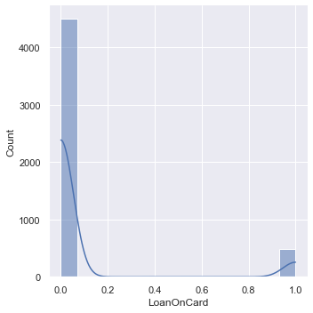

```python
sns.displot(Master_data['LoanOnCard'], kde=True);
```

Around 480 people already have 'Loan on Card'.

#### The Data is imbalance.

##### 2B. Check the percentage of missing values and impute if required.

Solution 2B:

```python
Master_data.isnull().sum()
```

```
ID                      0
Age                     0
CustomerSince           0
HighestSpend            0
ZipCode                 0
HiddenScore             0
MonthlyAverageSpend     0
Level                   0
Mortgage                0
Security                0
FixedDepositAccount     0
InternetBanking         0
CreditCard              0
LoanOnCard             20
dtype: int64
```

```python
print ('Percentage of Missing value for LoanOnCard:' , (Master_data['LoanOnCard'].isnull().sum()/ Master_data['LoanOnCard'].shape[0]) * 100)
```

```
Percentage of Missing value for LoanOnCard: 0.4
```

##### 2C. Check for unexpected values in each categorical variable and impute with best suitable value. [2 Marks]

[Unexpected values means if all values in a feature are 0/1 then ‘?’, ‘a’, 1.5 are unexpected values which needs treatment

Solution 2C:

```python
print ('Age',Master_data['Age'].unique())
print ('CustomerSince', Master_data['CustomerSince'].unique())
print ('HighestSpend : ', Master_data['HighestSpend'].unique())
print ('ZipCode' , Master_data['ZipCode'].unique())
print ('HiddenScore',Master_data['HiddenScore'].unique())
print ('MonthlyAverageSpend', Master_data['MonthlyAverageSpend'].unique())
print ('Security' , Master_data['Security'].unique())
print ( 'Level ', Master_data['Level'].unique())
print ('Mortgage' , Master_data['Mortgage'].unique())
print ('Security' , Master_data[ 'Security'].unique())
print ( 'Fixed Deposite', Master_data['FixedDepositAccount'].unique())
print ('InternetBanking', Master_data['InternetBanking'].unique())
print ('CreditCard' , Master_data['CreditCard'].unique())
print ('LoanOnCard' , Master_data['LoanOnCard'].unique())
```

```
Age [25 45 39 35 37 53 50 34 65 29 48 59 67 60 38 42 46 55 56 57 44 36 43 40
 30 31 51 32 61 41 28 49 47 62 58 54 33 27 66 24 52 26 64 63 23]
CustomerSince [ 1 19 15  9  8 13 27 24 10 39  5 23 32 41 30 14 18 21 28 31 11 16 20 35
  6 25  7 12 26 37 17  2 36 29  3 22 -1 34  0 38 40 33  4 -2 42 -3 43]
HighestSpend :  [ 49  34  11 100  45  29  72  22  81 180 105 114  40 112 130 193  21  25
  63  62  43 152  83 158  48 119  35  41  18  50 121  71 141  80  84  60
 132 104  52 194   8 131 190  44 139  93 188  39 125  32  20 115  69  85
 135  12 133  19  82 109  42  78  51 113 118  64 161  94  15  74  30  38
   9  92  61  73  70 149  98 128  31  58  54 124 163  24  79 134  23  13
 138 171 168  65  10 148 159 169 144 165  59  68  91 172  55 155  53  89
  28  75 170 120  99 111  33 129 122 150 195 110 101 191 140 153 173 174
  90 179 145 200 183 182  88 160 205 164  14 175 103 108 185 204 154 102
 192 202 162 142  95 184 181 143 123 178 198 201 203 189 151 199 224 218]
ZipCode [91107 90089 94720 94112 91330 92121 91711 93943 93023 94710 90277 93106
 94920 91741 95054 95010 94305 91604 94015 90095 91320 95521 95064 90064
```

[output cut: 74 more lines]

##### CustomerSince [ 1 19 15 9 8 13 27 24 10 39 5 23 32 41 30 14 18 21 28 31 11 16 20 35

6 25 7 12 26 37 17 2 36 29 3 22 -1 34 0 38 40 33 4 -2 42 -3 43] Has value which are -ve this is to be treated. Also LoanOnCard [nan 1. 0.] . this to be treated. Imputing :

```python
#Master_data[Master_data['CustomerSince'] < 0 ]   = 1

Master_data.loc[(Master_data['CustomerSince'] < 0 ),'CustomerSince']=1
Master_data['CustomerSince'].unique()
```

```
array([ 1, 19, 15,  9,  8, 13, 27, 24, 10, 39,  5, 23, 32, 41, 30, 14, 18,
       21, 28, 31, 11, 16, 20, 35,  6, 25,  7, 12, 26, 37, 17,  2, 36, 29,
        3, 22, 34,  0, 38, 40, 33,  4, 42, 43], dtype=int64)
```

```python
Master_data.head()
```

|  | ID | Age | CustomerSince | HighestSpend | ZipCode | HiddenScore | MonthlyAverageSpend | Level | Mortgage | Security | FixedDepositAccount | InternetBanking | CreditCard | LoanOnCard |
| --- | --- | --- | --- | --- | --- | --- | --- | --- | --- | --- | --- | --- | --- | --- |
| 0 | 1 | 25 | 1 | 49 | 91107 | 4 | 1.6 | 1 | 0 | 1 | 0 | 0 | 0 | NaN |
| 1 | 2 | 45 | 19 | 34 | 90089 | 3 | 1.5 | 1 | 0 | 1 | 0 | 0 | 0 | NaN |
| 2 | 3 | 39 | 15 | 11 | 94720 | 1 | 1.0 | 1 | 0 | 0 | 0 | 0 | 0 | NaN |
| 3 | 4 | 35 | 9 | 100 | 94112 | 1 | 2.7 | 2 | 0 | 0 | 0 | 0 | 0 | NaN |
| 4 | 5 | 35 | 8 | 45 | 91330 | 4 | 1.0 | 2 | 0 | 0 | 0 | 0 | 1 | NaN |

```python
#Master_data[Master_data['LoanOnCard'].isnull()] = 0
Master_data['LoanOnCard'].fillna(0, inplace=True)
Master_data['LoanOnCard'].unique()
```

```
array([0., 1.])
```

### 3. Data Preparation and model building: [10 Marks]

A. Split data into X and Y. [1 Marks] [Recommended to drop ID & ZipCode. LoanOnCard is target Variable]

B. Split data into train and test. Keep 25% data reserved for testing. [1 Marks]

C. Train a Supervised Learning Classification base model - Logistic Regression. [2 Marks]

D. Print evaluation metrics for the model and clearly share insights. [1 Marks]

E. Balance the data using the right balancing technique. [2 Marks]

```
    i. Check distribution of the target variable

    ii. Say output is class A : 20% and class B : 80%

    iii. Here you need to balance the target variable as 50:50.\

    iv. Try appropriate method to achieve the same.
```

F. Again train the same previous model on balanced data. [1 Marks]

G. Print evaluation metrics and clearly share differences observed. [2 Marks]

##### 3A. Split data into X and Y .

Solution 3A:

```python
Master_data_Copy = Master_data
Master_data.drop('ID', axis=1,  inplace=True)
```

```python
Master_data.drop('ZipCode', axis=1,  inplace=True)
```

```python
Master_data.head(2)
```

|  | Age | CustomerSince | HighestSpend | HiddenScore | MonthlyAverageSpend | Level | Mortgage | Security | FixedDepositAccount | InternetBanking | CreditCard | LoanOnCard |
| --- | --- | --- | --- | --- | --- | --- | --- | --- | --- | --- | --- | --- |
| 0 | 25 | 1 | 49 | 4 | 1.6 | 1 | 0 | 1 | 0 | 0 | 0 | 0.0 |
| 1 | 45 | 19 | 34 | 3 | 1.5 | 1 | 0 | 1 | 0 | 0 | 0 | 0.0 |

```python
#Splitting the Data
X = Master_data.loc[:, 'Age':'CreditCard']
Y = Master_data.loc[:, 'LoanOnCard':]
print (X.columns)
print (Y.columns)
```

```
Index(['Age', 'CustomerSince', 'HighestSpend', 'HiddenScore',
       'MonthlyAverageSpend', 'Level', 'Mortgage', 'Security',
       'FixedDepositAccount', 'InternetBanking', 'CreditCard'],
      dtype='object')
Index(['LoanOnCard'], dtype='object')
```

##### 3B. Split data into train and test. Keep 25% data reserved for testing.

Solution 3B:

```python
x_l_train , x_l_test, y_l_train , y_l_test = train_test_split(X,Y, test_size=0.25 , random_state=1)
print ('x_shape' , x_l_train.shape , 'y_shape' , y_l_train.shape)
print ('x_test' , x_l_test.shape , 'y_test' , y_l_test.shape)
```

```
x_shape (3750, 11) y_shape (3750, 1)
x_test (1250, 11) y_test (1250, 1)
```

##### 3C. Train a Supervised Learning Classification base model - Logistic Regression.

Solution 3C:

##### Handling Outliers:

#### Puting a Box Plot on the Original X (Indipendent Variables), to check if there are outlier and treat the data accordingly.

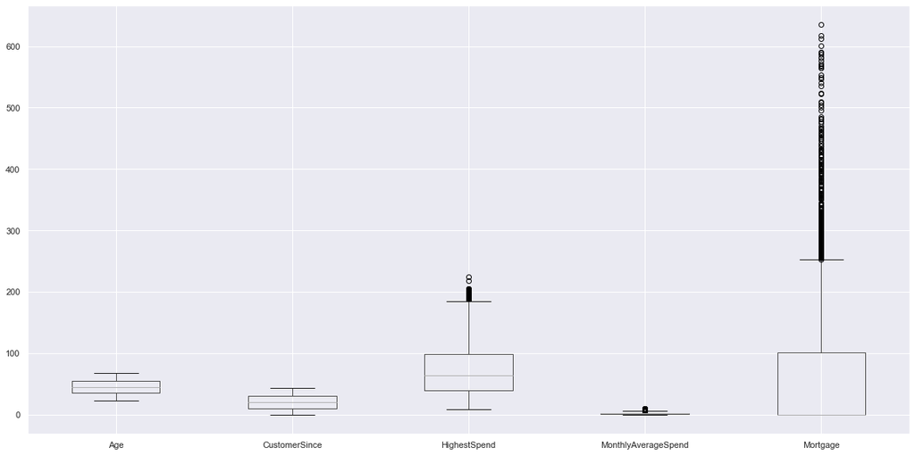

```python
X_copy_OL = X
pyp.figure(figsize=(20, 10))
X_copy_OL.boxplot()
pyp.show()
```

#### It is very clear from the box plot that 'HighestSpend', MonthlyAveragespend and Mortgage has quite a lot of outliers and will need some data treatement.

Understanding the distribution.

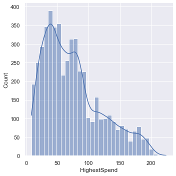

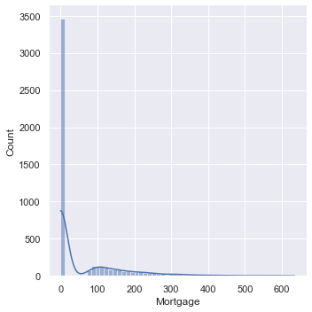

```python
sns.displot(X_copy_OL['HighestSpend'], kde='True');
sns.displot(X_copy_OL['Mortgage'], kde='True');
```

```python
X_copy_OL['HighestSpend'].describe()
```

```
count    5000.000000
mean       73.774200
std        46.033729
min         8.000000
25%        39.000000
50%        64.000000
75%        98.000000
max       224.000000
Name: HighestSpend, dtype: float64
```

```python
X_copy_OL['Mortgage'].describe()
```

```
count    5000.000000
mean       56.498800
std       101.713802
min         0.000000
25%         0.000000
50%         0.000000
75%       101.000000
max       635.000000
Name: Mortgage, dtype: float64
```

```python
X_copy_OL['Mortgage'].value_counts()
```

```
0      3462
98       17
119      16
89       16
91       16
       ...
547       1
458       1
505       1
361       1
541       1
Name: Mortgage, Length: 347, dtype: int64
```

```python
#Checking how may values are HighestSpend beyond the (1.5 * IQR) + 75%  = 186.5
MorethanIQR_15_HS = X_copy_OL[X_copy_OL['HighestSpend'] > 186].HighestSpend
print ('Original shape' , X_copy_OL['HighestSpend'].shape, 'MorethanIQR_15_HS shapre' , MorethanIQR_15_HS.shape)
```

```
Original shape (5000,) MorethanIQR_15_HS shapre (96,)
```

```python
#Checking how may values of Mortgage are beyond the (1.5 * IQR) + 75 %  = 252.5
MorethanIQR_15_M = X_copy_OL[X_copy_OL['Mortgage'] > 252].Mortgage
print ('Original shape' , X_copy_OL['Mortgage'].shape, 'MorethanIQR_15 shapre' , MorethanIQR_15_M.shape)
```

```
Original shape (5000,) MorethanIQR_15 shapre (291,)
```

#### As the Number of Rows are little high it will be good not to ignore it rather make these values at 1.5 IQR and test the Models again. Replacing all the value more than ( 1.5 IQR + Q3 ) with the value of ( 1.5 IQR + Q3).

```python
X_copy_OL.loc[(X_copy_OL['HighestSpend'] > 186 ),'HighestSpend'] = 186
X_copy_OL.loc[(X_copy_OL['Mortgage'] > 252 ),'Mortgage'] = 252
```

```python
X_copy_OL['Mortgage'].value_counts()
```

```
0      3462
252     293
98       17
119      16
91       16
       ...
206       1
235       1
191       1
195       1
173       1
Name: Mortgage, Length: 179, dtype: int64
```

```python
X_copy_OL['HighestSpend'].value_counts()
```

```
186    96
44     85
38     84
81     83
41     82
       ..
181     8
144     7
169     7
159     7
151     4
Name: HighestSpend, Length: 145, dtype: int64
```

#### Converting Y to int as the value is just 0 or 1`.

```python
Y['LoanOnCard'] = Y['LoanOnCard'].astype(int)
print (Y['LoanOnCard'].value_counts())
Y.head(3)
```

```
0    4520
1     480
Name: LoanOnCard, dtype: int64
```

|  | LoanOnCard |
| --- | --- |
| 0 | 0 |
| 1 | 0 |
| 2 | 0 |

```python
#Splitting the data Again After the Outlier Handling .
x_OL_train , x_OL_test, y_OL_train , y_OL_test = train_test_split(X_copy_OL,Y, test_size=0.25 , random_state=1)
```

```python
from sklearn.linear_model import LogisticRegression
from sklearn import metrics

LogisticReg = LogisticRegression(solver='liblinear')
LogisticReg.fit(x_OL_train, np.ravel (y_OL_train))
```

```
LogisticRegression(solver='liblinear')
```

```python
accuracy_score = LogisticReg.score(x_OL_test, y_OL_test)
accuracy_score
```

```
0.9464
```

```python
predicted_y = LogisticReg.predict(x_OL_test)
```

```python
accuracy = metrics.accuracy_score(y_OL_test, predicted_y);
accuracy
```

```
0.9464
```

##### 3D. Print evaluation metrics for the model and clearly share insights.

Solution 3D:

```python
#Printing classificaiton report.
print (metrics.classification_report(y_OL_test,  predicted_y))
```

```
              precision    recall  f1-score   support

           0       0.96      0.99      0.97      1121
           1       0.83      0.60      0.70       129

    accuracy                           0.95      1250
   macro avg       0.89      0.80      0.84      1250
weighted avg       0.94      0.95      0.94      1250
```

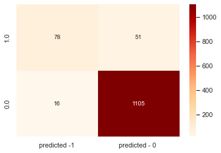

```python
#printing Confustion matrix.
cf_mx = metrics.confusion_matrix(y_OL_test, predicted_y, labels=[1,0])
df_cfmx = pd.DataFrame(cf_mx, index =[i for i in [1.0,0.0]], columns= [i for i in ['predicted -1','predicted - 0 ']])
sns.heatmap(df_cfmx, annot=True, fmt='g', cmap="OrRd");
```

#### Putting up ROC score.

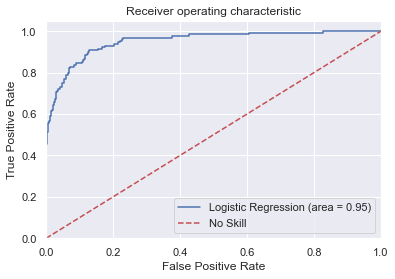

```python
#AUC ROC curve
from sklearn.metrics import roc_auc_score
from sklearn.metrics import roc_curve

logit_roc_auc = roc_auc_score(y_OL_test, LogisticReg.predict_proba(x_OL_test)[:,1])
fpr, tpr, thresholds = roc_curve(y_OL_test, LogisticReg.predict_proba(x_OL_test)[:,1])
pyp.figure()
pyp.plot(fpr,tpr, label='Logistic Regression (area = %0.2f)' % logit_roc_auc)
pyp.plot([0, 1], [0, 1],'r--',label='No Skill')
pyp.xlim([0.0, 1.0])
pyp.ylim([0.0, 1.05])
pyp.xlabel('False Positive Rate')
pyp.ylabel('True Positive Rate')
pyp.title('Receiver operating characteristic')
pyp.legend(loc="lower right")
pyp.savefig('Log_ROC')
pyp.show()
```

```
Best Threshold=0.073901, G-Mean=0.889
```

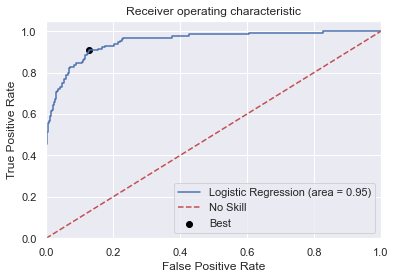

```python
# roc curve for logistic regression model with optimal threshold
from numpy import sqrt
from numpy import argmax

logit_roc_auc = roc_auc_score(y_OL_test, LogisticReg.predict_proba(x_OL_test)[:,1])
fpr, tpr, thresholds = roc_curve(y_OL_test, LogisticReg.predict_proba(x_OL_test)[:,1])
# calculate the g-mean for each threshold
gmeans = sqrt(tpr * (1-fpr))
# locate the index of the largest g-mean
ix = argmax(gmeans)
print('Best Threshold=%f, G-Mean=%.3f' % (thresholds[ix], gmeans[ix]))
pyp.figure()
pyp.plot(fpr, tpr, label='Logistic Regression (area = %0.2f)' % logit_roc_auc)
pyp.plot([0, 1], [0, 1],'r--',label='No Skill')
pyp.scatter(fpr[ix], tpr[ix], marker='o', color='black', label='Best')
pyp.xlim([0.0, 1.0])
pyp.ylim([0.0, 1.05])
pyp.xlabel('False Positive Rate')
pyp.ylabel('True Positive Rate')
pyp.title('Receiver operating characteristic')
pyp.legend(loc="lower right")
pyp.savefig('Log_ROC')
pyp.show()
```

### From the above evaluation metrice's it is quite clear that the results as very bias toward the Majority class , which is 'LoanOnCard = 0'. This model will need a revisit with balance data.

##### 3E. Balance the data using the right balancing technique. [2 Marks]

```
    i. Check distribution of the target variable

    ii. Say output is class A : 20% and class B : 80%

    iii. Here you need to balance the target variable as 50:50.\

    iv. Try appropriate method to achieve the same.

    Solution 3E:
```

```python
#Distribution of the target variable
Master_data["LoanOnCard"].value_counts()
```

```
0.0    4520
1.0     480
Name: LoanOnCard, dtype: int64
```

```python
#As its a Financial transactions , Randomly Under-Sampling 'LoanOnCard = 0' will lead to unreal representaion in the real world.
#Therefore data generation using SMOTE is more appropriate as the data set is not too large as well.

from imblearn.over_sampling import SMOTE
sm = SMOTE(random_state = 2)
x_OL_train_sm, y_OL_train_sm = sm.fit_sample(x_OL_train, np.ravel (y_OL_train))
```

```python
#Original imbalanced 'LoanOnCard'
y_OL_train.value_counts()
```

```
LoanOnCard
0             3399
1              351
dtype: int64
```

```python
#SMOTE balanced 'LoanOnCard'
df_y_l_train_sm = pd.DataFrame(y_OL_train_sm)
df_y_l_train_sm.value_counts()
```

```
0    3399
1    3399
dtype: int64
```

### The data is now balanced at 50:50.

##### 3F. Again train the same previous model on balanced data.

Solution 3F:

```python
#Recalculating Logical Regression
LogisticReg.fit(x_OL_train_sm, np.ravel (y_OL_train_sm))
```

```
LogisticRegression(solver='liblinear')
```

##### 3G. Print evaluation metrics and clearly share differences observed.

Solution 3G:

```python
accuracy_score_sm = LogisticReg.score(x_OL_test, y_OL_test)
accuracy_score_sm
```

```
0.9056
```

```python
predicted_y_sm = LogisticReg.predict(x_OL_test)
```

```python
print (metrics.classification_report(y_OL_test,  predicted_y_sm))
```

```
              precision    recall  f1-score   support

           0       0.98      0.91      0.95      1121
           1       0.53      0.87      0.65       129

    accuracy                           0.91      1250
   macro avg       0.75      0.89      0.80      1250
weighted avg       0.94      0.91      0.92      1250
```

#### The accuracy has indeed reduced , but looking at the recall, it is quite a balance outcome . This is a better representation of the real-world and this model expected to perform better prediction.

### 4. Performance Improvement: [10 Marks]

A. Train a base model each for SVM, KNN. [4 Marks]

B. Tune parameters for each of the models wherever required and finalize a model. [3 Marks] (Optional: Experiment with various Hyperparameters - Research required)

C. Print evaluation metrics for final model. [1 Marks]

D. Share improvement achieved from base model to final model. [2 Mark

##### 4A. Train a base model each for SVM, KNN.

Solution 3A:

```python
#Calculation for SVM
from sklearn.svm import SVC

svc = SVC()
svc.fit(x_OL_train_sm, np.ravel (y_OL_train_sm))


print("Accuracy on training set SVC: ", svc.score(x_OL_train_sm, np.ravel (y_OL_train_sm)))
print("Accuracy on test set SVC: ", svc.score(x_OL_test, y_OL_test))
```

```
Accuracy on training set SVC:  0.8851132686084142
Accuracy on test set SVC:  0.8184
```

```python
#Evaluation Matrices for SVM
predicted_y_SVM= svc.predict(x_OL_test)
print (metrics.classification_report(y_OL_test,  predicted_y_SVM))
```

```
              precision    recall  f1-score   support

           0       0.98      0.81      0.89      1121
           1       0.35      0.89      0.50       129

    accuracy                           0.82      1250
   macro avg       0.67      0.85      0.70      1250
weighted avg       0.92      0.82      0.85      1250
```

```python
#Calculation for KNN.
knncmp = KNeighborsClassifier(n_neighbors= 5, weights='distance')
knncmp.fit(x_OL_train_sm, np.ravel (y_OL_train_sm))
print ('KNN Training score', knncmp.score(x_OL_train_sm, np.ravel (y_OL_train_sm)))
print ('KNN Testing score', knncmp.score(x_OL_test, y_OL_test))
yknn_predict = knncmp.predict(x_OL_test)

print (metrics.classification_report (y_OL_test, yknn_predict))
```

```
KNN Training score 1.0
KNN Testing score 0.8608
              precision    recall  f1-score   support

           0       0.98      0.86      0.92      1121
           1       0.41      0.84      0.55       129

    accuracy                           0.86      1250
   macro avg       0.70      0.85      0.74      1250
weighted avg       0.92      0.86      0.88      1250
```

### 4B. Tune parameters for each of the models wherever required and finalize a model

#### Applying MinMaxModel for Logical Regression Tuning on the Balanced data.

```python
from sklearn.preprocessing import MinMaxScaler

scaler = MinMaxScaler(feature_range = (0,1))

scaler.fit(x_OL_train_sm)
X_mm_train = scaler.transform(x_OL_train_sm)
X_mm_test = scaler.transform(x_OL_test)

LogisticReg.fit(X_mm_train, np.ravel (y_OL_train_sm))
accuracy_score_mm = LogisticReg.score(X_mm_test, y_OL_test)

accuracy_score_mm
```

```
0.8984
```

#### MimMax Scaler is not much helpful.

#### Tunning Logistic Regression with GridSearchCV

```python
from sklearn.model_selection import GridSearchCV
tuningparameters = {
    'penalty' : ['l1','l2'],
    'C'       : np.logspace(-3,3,7),
    'solver'  : ['liblinear'],
}
lrg = GridSearchCV(LogisticReg, tuningparameters,verbose = 1,cv=3, n_jobs = -1)

lrgVal= lrg.fit(x_OL_train_sm, np.ravel (y_OL_train_sm))
```

```
Fitting 3 folds for each of 14 candidates, totalling 42 fits
```

```python
print ('Logical Regression Best Parameters')
print ('lrgVal.best_score_', lrgVal.best_score_)
print ('lrgVal.best_params_', lrgVal.best_params_)
```

```
Logical Regression Best Parameters
lrgVal.best_score_ 0.9167402177110916
lrgVal.best_params_ {'C': 100.0, 'penalty': 'l1', 'solver': 'liblinear'}
```

```python
LogisticReg_Best = LogisticRegression( C = 1, penalty='l1', solver='liblinear')
LogisticReg_Best.fit(x_OL_train_sm, np.ravel (y_OL_train_sm))
```

```
LogisticRegression(C=1, penalty='l1', solver='liblinear')
```

```python
accuracy_score_sm = LogisticReg_Best.score(x_OL_test, y_OL_test)
print ('Logical Regression accuracy_score : ' , accuracy_score_sm)
predicted_y_sm = LogisticReg_Best.predict(x_OL_test)
print (metrics.classification_report(y_OL_test,  predicted_y_sm))
```

```
Logical Regression accuracy_score :  0.9048
              precision    recall  f1-score   support

           0       0.98      0.91      0.94      1121
           1       0.52      0.86      0.65       129

    accuracy                           0.90      1250
   macro avg       0.75      0.89      0.80      1250
weighted avg       0.94      0.90      0.91      1250
```

##### Tunning KNN with GridSearchCV

```python
grid_params = { 'n_neighbors' : [5,7,9,11,13,15],
               'weights' : ['uniform','distance'],
               'metric' : ['minkowski','euclidean','manhattan']}

gs = GridSearchCV(KNeighborsClassifier(), grid_params, verbose = 1, cv=3, n_jobs = -1)
g_knn = gs.fit(x_OL_train_sm, np.ravel (y_OL_train_sm))
```

```
Fitting 3 folds for each of 36 candidates, totalling 108 fits
```

```python
print ('KNN Best Parameters')
print ('g_knn.best_score_', g_knn.best_score_)
print ('g_knn.best_params_', g_knn.best_params_)
```

```
KNN Best Parameters
g_knn.best_score_ 0.9382171226831421
g_knn.best_params_ {'metric': 'manhattan', 'n_neighbors': 5, 'weights': 'distance'}
```

```python
knn_Best = KNeighborsClassifier(n_neighbors= 5, weights='distance', metric='manhattan')
knn_Best.fit(x_OL_train_sm, np.ravel (y_OL_train_sm))
print ('KNN Training score', knn_Best.score(x_OL_train_sm, np.ravel (y_OL_train_sm)))
print ('KNN Testing Accuracy score', knn_Best.score(x_OL_test, y_OL_test))
yknn_predict = knn_Best.predict(x_OL_test)

print (metrics.classification_report (y_OL_test, yknn_predict))
```

```
KNN Training score 1.0
KNN Testing Accuracy score 0.892
              precision    recall  f1-score   support

           0       0.98      0.90      0.94      1121
           1       0.49      0.83      0.61       129

    accuracy                           0.89      1250
   macro avg       0.73      0.86      0.78      1250
weighted avg       0.93      0.89      0.90      1250
```

##### Tunning SVM :

As it is taking quite long to perform GridSearchCV, performing manual tuning.

```python
#SVM_params = {'C': [3], 'gamma': [0.05, 1, ],'kernel': ['rbf', 'sigmoid', 'linear']}

#svgrid = GridSearchCV(svc, SVM_params, verbose = 1, cv=3, n_jobs = -1)
g_SVM = svgrid.fit(x_OL_train_sm, np.ravel (y_OL_train_sm))
```

[output not shown]

```python
#print ('SVM Best Parameters')
#print ('g_SVM.best_score_', g_SVM.best_score_)
#print ('g_SVM.best_params_', g_SVM.best_params_)
```

```python
svm_Best = SVC(C=3, gamma=0.05, kernel='rbf')
svm_Best.fit(x_OL_train_sm, np.ravel (y_OL_train_sm))
print ('SVM Training score', svm_Best.score(x_OL_train_sm, np.ravel (y_OL_train_sm)))
print ('SVM Testing accuracy score', svm_Best.score(x_OL_test, y_OL_test))
ysvm_predict = svm_Best.predict(x_OL_test)

print (metrics.classification_report (y_OL_test, ysvm_predict))
```

```
SVM Training score 0.9989702853780523
SVM Testing accuracy score 0.928
              precision    recall  f1-score   support

           0       0.95      0.97      0.96      1121
           1       0.69      0.56      0.62       129

    accuracy                           0.93      1250
   macro avg       0.82      0.76      0.79      1250
weighted avg       0.92      0.93      0.92      1250
```

#### Checking is Linear fits better as the recall value differs a lot .

```python
svm_Best = SVC(C=3, gamma=0.05, kernel='linear')
svm_Best.fit(x_OL_train_sm, np.ravel (y_OL_train_sm))
print ('SVM Training score', svm_Best.score(x_OL_train_sm, np.ravel (y_OL_train_sm)))
print ('SVM Testing accuracy score', svm_Best.score(x_OL_test, y_OL_test))
ysvm_predict = svm_Best.predict(x_OL_test)

print (metrics.classification_report (y_OL_test, ysvm_predict))
```

```
SVM Training score 0.9158576051779935
SVM Testing accuracy score 0.892
              precision    recall  f1-score   support

           0       0.98      0.89      0.94      1121
           1       0.49      0.87      0.62       129

    accuracy                           0.89      1250
   macro avg       0.74      0.88      0.78      1250
weighted avg       0.93      0.89      0.90      1250
```

### SVM is chosen.

===================================================== Logical Regression accuracy_score : 0.904 precision recall f1-score support

```
       0       0.98      0.91      0.94      1121
       1       0.52      0.86      0.65       129

accuracy                           0.90      1250
```

====================================================== KNN Testing Accuracy score 0.892 precision recall f1-score support

```
       0       0.98      0.90      0.94      1121
       1       0.49      0.83      0.61       129

accuracy                           0.89      1250
```

macro avg 0.73 0.86 0.78 1250 weighted avg 0.93 0.89 0.90 1250

======================================================

[output not shown]

##### 4C. Print evaluation metrics for final model.

Solution 4C:

### Conclusion : From all the test above SVM turns out to be a better model.

[output not shown]

##### 4D. Share improvement achieved from base model to final model.

Solution 4D:

2) The Values of precision, F1 scores improved substancially. Recall is reduced but this value is still considered OK.